# Lab 2: Super Learner

Causal Machine Learning

Stijn Vansteelandt and Federico Bertoia, Ghent University

2026-03-16

## 0. Introduction

The goal of this lab is to get familiar with the `SuperLearner` R package. We analyze the [Student Dropout Prediction Dataset](https://www.kaggle.com/datasets/meharshanali/student-dropout-prediction-dataset), which simulates a realistic academic environment for 10,000 students. Beyond predicting dropout (binary outcome), we also predict GPA (continuous outcome), giving us one task of each type. For a comprehensive reference on the package’s functions and arguments, see the [SuperLearner documentation](https://cran.r-project.org/web/packages/SuperLearner/refman/SuperLearner.html).

```r
# ── Packages ──────────────────────────────────────────────────────────────────
library(readr)
library(dplyr)
library(tidyr)
library(ggplot2)
library(ggcorrplot)
library(fastDummies)
library(SuperLearner)
library(pROC)

# ── Reproducibility ───────────────────────────────────────────────────────────
set.seed(123)

# ── Load data ─────────────────────────────────────────────────────────────────
df_path <- "C:/Users/feder/OneDrive - UGent/Desktop/GitHub/Labs-Causal-Machine-Learning/Lab 2 - Super Learner/student_dropout_dataset_v3.csv"

df <- read_csv(df_path)

# Subsample for speed during this lab
df <- slice_sample(df, n = 2000)

# ── Initial inspection ────────────────────────────────────────────────────────
glimpse(df)
```

```
## Rows: 2,000
## Columns: 19
## $ Student_ID            <dbl> 2463, 2511, 8718, 2986, 1842, 9334, 3371, 4761, …
## $ Age                   <dbl> 22.1, 22.1, 21.3, 18.9, 17.0, 22.9, 20.8, 18.2, …
## $ Gender                <chr> "Male", "Female", "Male", "Male", "Female", "Mal…
## $ Family_Income         <dbl> 25000, 29611, 25000, 25205, 25000, 25000, 63444,…
## $ Internet_Access       <chr> "Yes", "Yes", "Yes", "Yes", "Yes", "Yes", "Yes",…
## $ Study_Hours_per_Day   <dbl> 2.06, 3.48, 3.52, 3.06, 3.69, 5.57, 6.00, 2.39, …
## $ Attendance_Rate       <dbl> 75.9, 78.6, 79.6, 62.9, 86.6, 73.9, 85.3, 75.0, …
## $ Assignment_Delay_Days <dbl> 1, 5, 2, 3, 3, 0, 2, 2, 1, 3, 1, 2, 0, 2, 1, 2, …
## $ Travel_Time_Minutes   <dbl> 44.8, 42.2, 36.8, 37.5, 37.0, 22.2, 42.2, 28.9, …
## $ Part_Time_Job         <chr> "No", "No", "Yes", "Yes", "No", "Yes", "Yes", "N…
## $ Scholarship           <chr> "No", "Yes", "No", "No", "No", "Yes", "No", "Yes…
## $ Stress_Index          <dbl> 7.5, 3.5, 7.5, 7.2, 6.6, 4.9, 1.0, 4.2, 7.9, 3.6…
## $ GPA                   <dbl> 0.21, 2.36, 0.00, 0.74, 2.26, 2.64, 4.00, 2.22, …
## $ Semester_GPA          <dbl> 0.52, 2.58, 0.22, 0.57, 2.28, 2.63, 4.00, 1.75, …
## $ CGPA                  <dbl> 0.51, 2.53, 0.18, 0.57, 2.26, 2.68, 4.00, 1.76, …
## $ Semester              <chr> "Year 2", "Year 3", "Year 2", "Year 4", "Year 3"…
## $ Department            <chr> "CS", "Arts", "Arts", "Arts", "Arts", "Arts", "E…
## $ Parental_Education    <chr> "PhD", "Master", "Master", "Bachelor", "Master",…
## $ Dropout               <dbl> 1, 0, 0, 1, 1, 0, 0, 0, 1, 0, 0, 1, 0, 0, 0, 0, …
```

```r
# ── Preprocessing ─────────────────────────────────────────────────────────────
df <- df %>%
  # Drop identifier and redundant columns
  select(-Student_ID, -Semester_GPA, -CGPA) %>%
  # Remove incomplete cases
  drop_na()

# Confirm no remaining missingness
stopifnot(all(colSums(is.na(df)) == 0))
```

## 1. Data Visualization

We begin with a visual exploration of the dataset. We first examine the distribution of categorical variables and their relationship with the binary outcome **Dropout**. We then do the same for the continuous outcome **GPA**.

### 1.1 Marginal distributions of categorical variables

The bar charts below show the distribution of each categorical variable in the dataset, alongside the binary target `Dropout`.

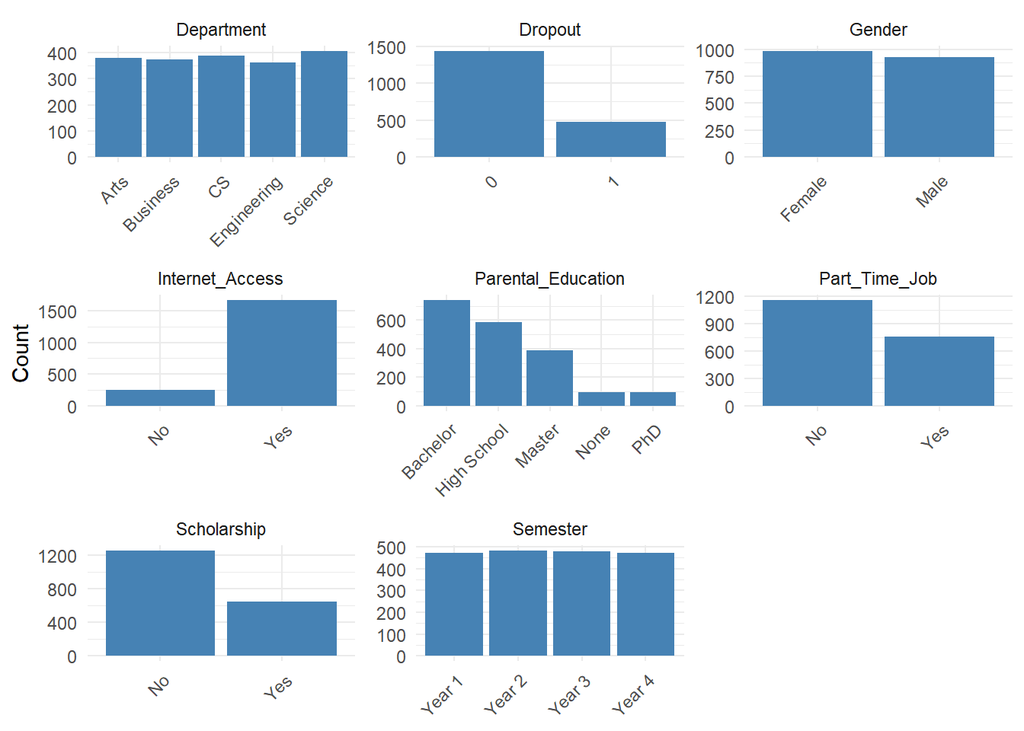

```r
df %>%
  select(where(is.character), Dropout) %>%
  mutate(Dropout = as.character(Dropout)) %>%
  pivot_longer(cols = everything(), names_to = "variable", values_to = "value") %>%
  ggplot(aes(x = value)) +
  geom_bar(fill = "steelblue") +
  facet_wrap(~variable, scales = "free") +
  theme_minimal() +
  theme(axis.text.x = element_text(angle = 45, hjust = 1)) +
  labs(x = NULL, y = "Count")
```

### 1.2 Categorical variables stratified by Dropout

To assess potential predictive signal, we plot the dropout rate within each category using stacked proportion bars. Categories with large imbalances across the two `Dropout` levels are likely informative predictors.

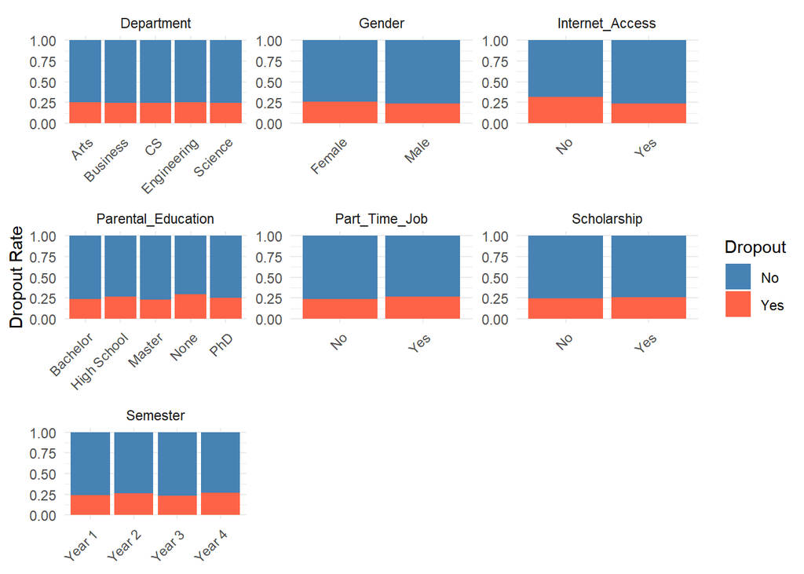

```r
df %>%
  select(where(is.character), Dropout) %>%
  pivot_longer(cols = -Dropout, names_to = "variable", values_to = "value") %>%
  ggplot(aes(x = value, fill = factor(Dropout))) +
  geom_bar(position = "fill") +
  facet_wrap(~variable, scales = "free") +
  theme_minimal() +
  theme(axis.text.x = element_text(angle = 45, hjust = 1)) +
  labs(x = NULL, y = "Dropout Rate", fill = "Dropout") +
  scale_fill_manual(values = c("steelblue", "tomato"), labels = c("No", "Yes"))
```

### 1.3 Distribution of GPA

Since GPA is our continuous outcome, we inspect its marginal distribution via a histogram overlaid with a density curve.

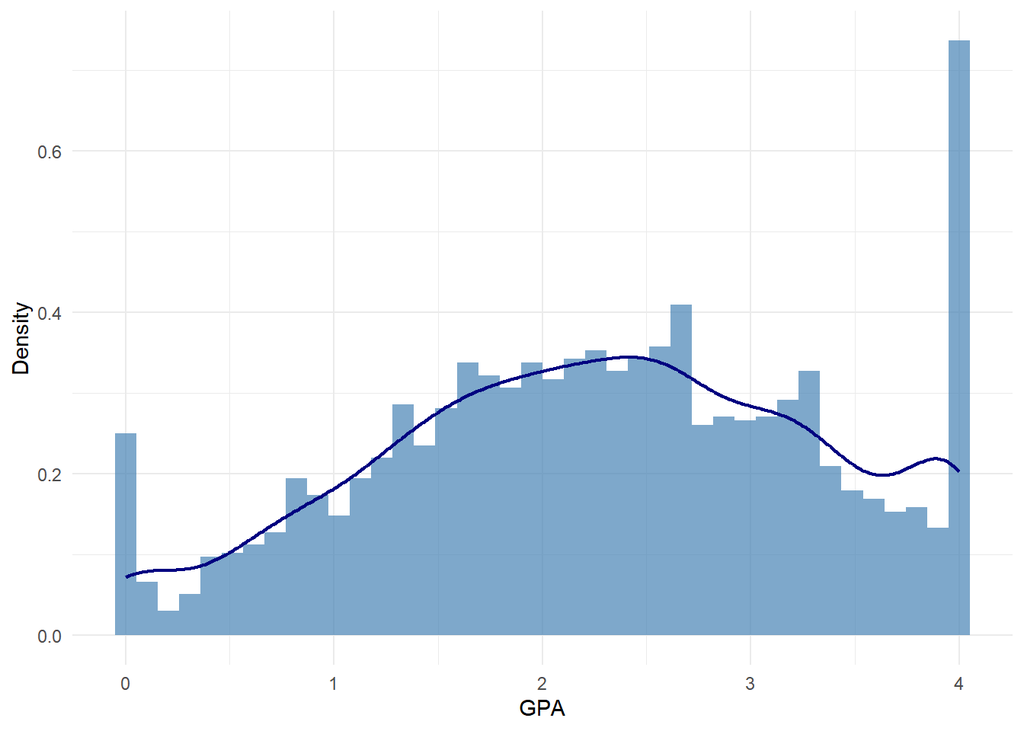

```r
ggplot(df, aes(x = GPA)) +
  geom_histogram(aes(y = after_stat(density)), bins = 40,
                 fill = "steelblue", alpha = 0.7) +
  geom_density(color = "navy", linewidth = 0.8) +
  theme_minimal() +
  labs(x = "GPA", y = "Density")
```

### 1.4 GPA stratified by Dropout

Students who drop out may have systematically lower GPAs. The overlapping density plots below let us assess this visually.

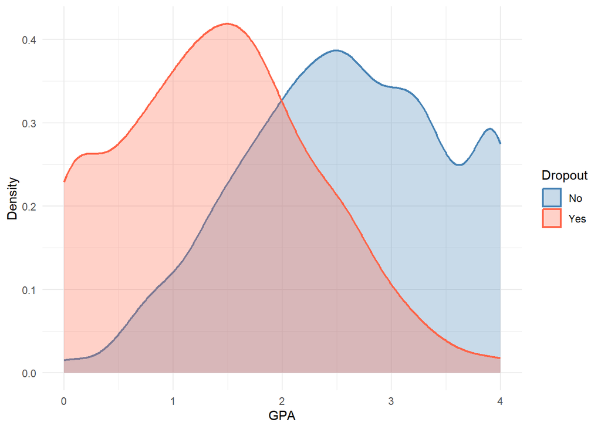

```r
df %>%
  mutate(Dropout = factor(Dropout, labels = c("No", "Yes"))) %>%
  ggplot(aes(x = GPA, fill = Dropout, color = Dropout)) +
  geom_density(alpha = 0.3, linewidth = 0.8) +
  theme_minimal() +
  scale_fill_manual(values = c("steelblue", "tomato")) +
  scale_color_manual(values = c("steelblue", "tomato")) +
  labs(x = "GPA", y = "Density", fill = "Dropout", color = "Dropout")
```

### 1.5 GPA vs. numeric predictors

A scatterplot matrix (or individual scatter plots) can reveal linear and non-linear associations between GPA and the numeric features.

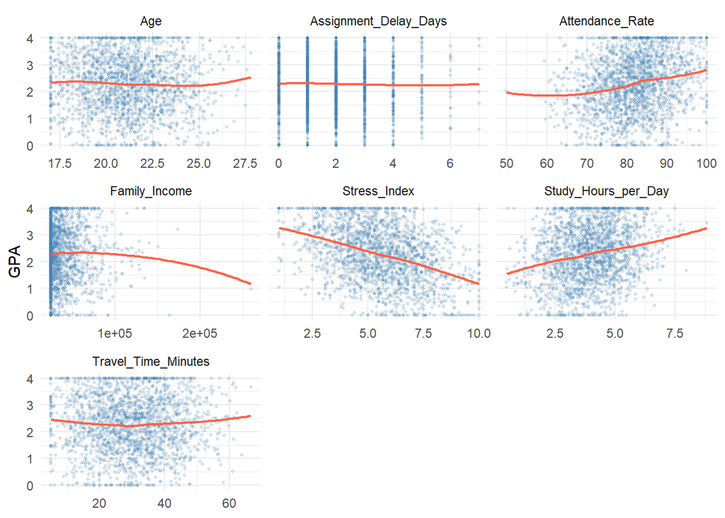

```r
df %>%
  select(where(is.numeric), -Dropout) %>%
  pivot_longer(cols = -GPA, names_to = "variable", values_to = "value") %>%
  ggplot(aes(x = value, y = GPA)) +
  geom_point(alpha = 0.2, size = 0.8, color = "steelblue") +
  geom_smooth(method = "loess", se = FALSE, color = "tomato", linewidth = 0.8) +
  facet_wrap(~variable, scales = "free_x") +
  theme_minimal() +
  labs(x = NULL, y = "GPA")
```

## 2. Categorical Encoding

Before fitting any model, we encode categorical variables numerically. Binary variables are mapped to 0/1, ordinal variables to consecutive integers respecting their natural order, and the unordered `Department` variable is one-hot encoded (with one level dropped to avoid collinearity).

```r
# Binary: Yes/No and Male/Female -> 0/1
df <- df %>%
  mutate(
    Gender          = ifelse(Gender == "Male", 1L, 0L),
    Internet_Access = ifelse(Internet_Access == "Yes", 1L, 0L),
    Part_Time_Job   = ifelse(Part_Time_Job == "Yes", 1L, 0L),
    Scholarship     = ifelse(Scholarship == "Yes", 1L, 0L)
  )

# Ordinal: factor levels -> integer (preserving order)
df <- df %>%
  mutate(
    Semester = factor(Semester,
                      levels = c("Year 1", "Year 2", "Year 3", "Year 4"),
                      ordered = TRUE) %>% as.integer(),
    Parental_Education = factor(Parental_Education,
                                levels = c("None", "High School", "Bachelor", "Master", "PhD"),
                                ordered = TRUE) %>% as.integer()
  )

# Nominal: one-hot encode Department (drop first dummy to avoid collinearity)
df <- dummy_cols(df,
                 select_columns          = "Department",
                 remove_first_dummy      = TRUE,
                 remove_selected_columns = TRUE)
```

## 3. Correlation with Outcomes

We compute Pearson correlations of all predictors with each outcome separately. This gives a quick, linear summary of marginal associations.

### 3.1 Correlation with Dropout

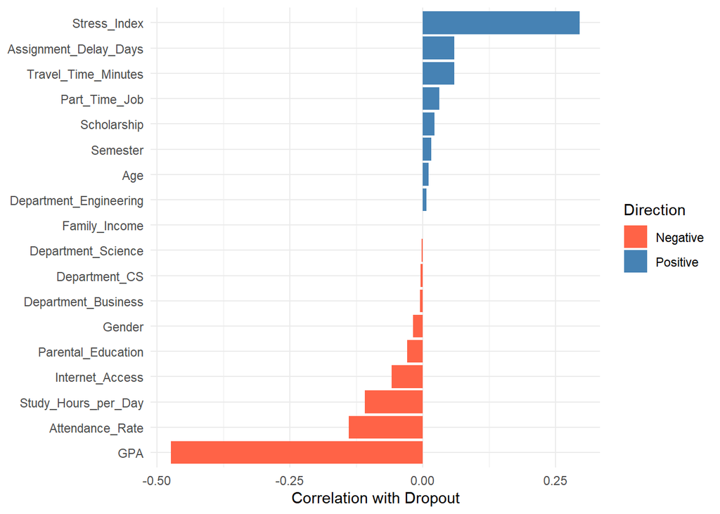

```r
df %>%
  cor() %>%
  as.data.frame() %>%
  select(Dropout) %>%
  tibble::rownames_to_column("variable") %>%
  filter(variable != "Dropout") %>%
  ggplot(aes(x = reorder(variable, Dropout), y = Dropout, fill = Dropout > 0)) +
  geom_col() +
  coord_flip() +
  theme_minimal() +
  scale_fill_manual(values = c("tomato", "steelblue"), labels = c("Negative", "Positive")) +
  labs(x = NULL, y = "Correlation with Dropout", fill = "Direction")
```

### 3.2 Correlation with GPA

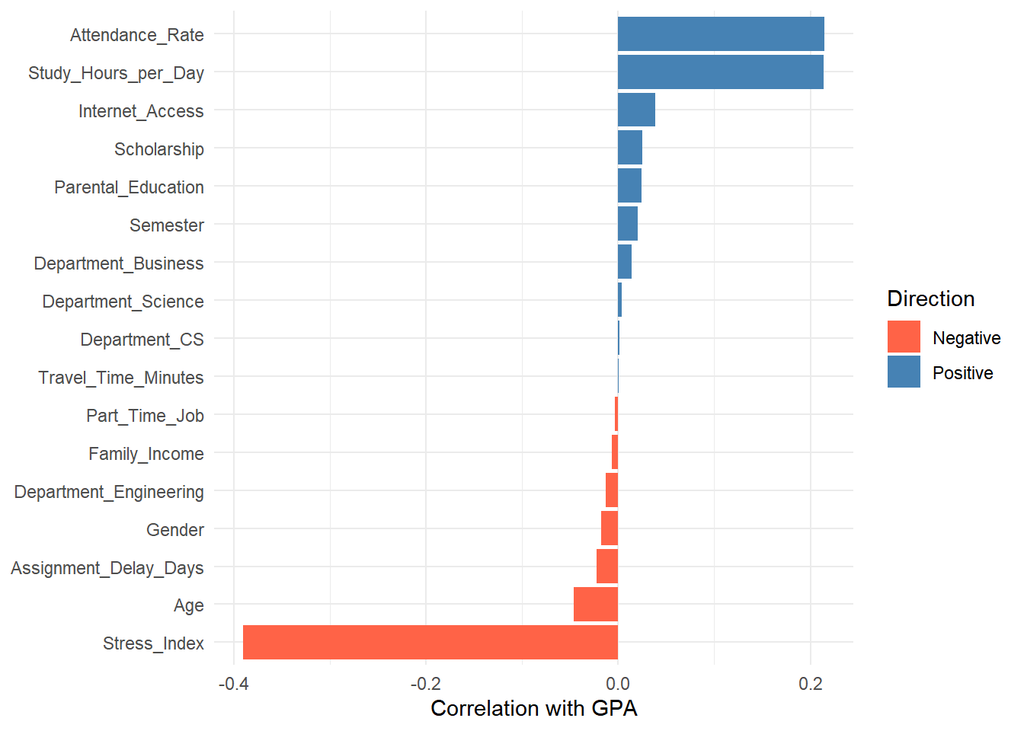

```r
df %>%
  select(-Dropout) %>%
  cor() %>%
  as.data.frame() %>%
  select(GPA) %>%
  tibble::rownames_to_column("variable") %>%
  filter(variable != "GPA") %>%
  ggplot(aes(x = reorder(variable, GPA), y = GPA, fill = GPA > 0)) +
  geom_col() +
  coord_flip() +
  theme_minimal() +
  scale_fill_manual(values = c("tomato", "steelblue"), labels = c("Negative", "Positive")) +
  labs(x = NULL, y = "Correlation with GPA", fill = "Direction")
```

## 4. Super Learner on the Entire Dataset

As a first step, we fit the Super Learner on the full dataset without cross-fitting. This gives us in-sample performance metrics, which will later serve as a baseline to compare against the cross-validated estimates. We evaluate performance using two measures. The **MSE** estimates the expected squared difference between the predicted value and the true value — more informative for a continuous outcome. The **AUC** is the area under the ROC curve, which equals the probability that the model ranks a randomly chosen dropout student higher than a randomly chosen non-dropout student — it measures discrimination ability regardless of the chosen classification threshold.

```r
# --- Check available learners ---
listWrappers()
```

```
##  [1] "SL.bartMachine"      "SL.bayesglm"         "SL.biglasso"
##  [4] "SL.caret"            "SL.caret.rpart"      "SL.cforest"
##  [7] "SL.earth"            "SL.gam"              "SL.gbm"
## [10] "SL.glm"              "SL.glm.interaction"  "SL.glmnet"
## [13] "SL.ipredbagg"        "SL.kernelKnn"        "SL.knn"
## [16] "SL.ksvm"             "SL.lda"              "SL.leekasso"
## [19] "SL.lm"               "SL.loess"            "SL.logreg"
## [22] "SL.mean"             "SL.nnet"             "SL.nnls"
## [25] "SL.polymars"         "SL.qda"              "SL.randomForest"
## [28] "SL.ranger"           "SL.ridge"            "SL.rpart"
## [31] "SL.rpartPrune"       "SL.speedglm"         "SL.speedlm"
## [34] "SL.step"             "SL.step.forward"     "SL.step.interaction"
## [37] "SL.stepAIC"          "SL.svm"              "SL.template"
## [40] "SL.xgboost"
```

```
## [1] "All"
## [1] "screen.corP"           "screen.corRank"        "screen.glmnet"
## [4] "screen.randomForest"   "screen.SIS"            "screen.template"
## [7] "screen.ttest"          "write.screen.template"
```

### 4.1 Dropout

```r
# Define feature matrix
X_dropout <- df %>% select(-Dropout)

# Candidate learners
SL.library <- c("SL.mean", "SL.glm", "SL.ranger", "SL.gam", "SL.earth")

# Fit Super Learner on full data
sl_fit_dropout <- SuperLearner(
  Y          = df$Dropout,
  X          = X_dropout,
  SL.library = SL.library,
  family     = binomial(),
  method     = "method.NNLS",
  cvControl  = list(V = 5)
)

sl_fit_dropout
```

```
##
## Call:
## SuperLearner(Y = df$Dropout, X = X_dropout, family = binomial(), SL.library = SL.library,
##     method = "method.NNLS", cvControl = list(V = 5))
##
##
##                    Risk       Coef
## SL.mean_All   0.1869916 0.00000000
## SL.glm_All    0.1388251 0.47264775
## SL.ranger_All 0.1394320 0.43983582
## SL.gam_All    0.1394676 0.00000000
## SL.earth_All  0.1434794 0.08751643
```

```r
# In-sample predictions
Y_hat_dropout <- predict(sl_fit_dropout, newdata = X_dropout)$pred

# MSE
mse_dropout <- mean((df$Dropout - Y_hat_dropout)^2)
cat("In-sample MSE:", round(mse_dropout, 4), "\n")
```

```
## In-sample MSE: 0.0695
```

```r
# AUC
roc_dropout <- roc(df$Dropout, Y_hat_dropout)
cat("In-sample AUC:", round(auc(roc_dropout), 4), "\n")
```

```
## In-sample AUC: 0.9834
```

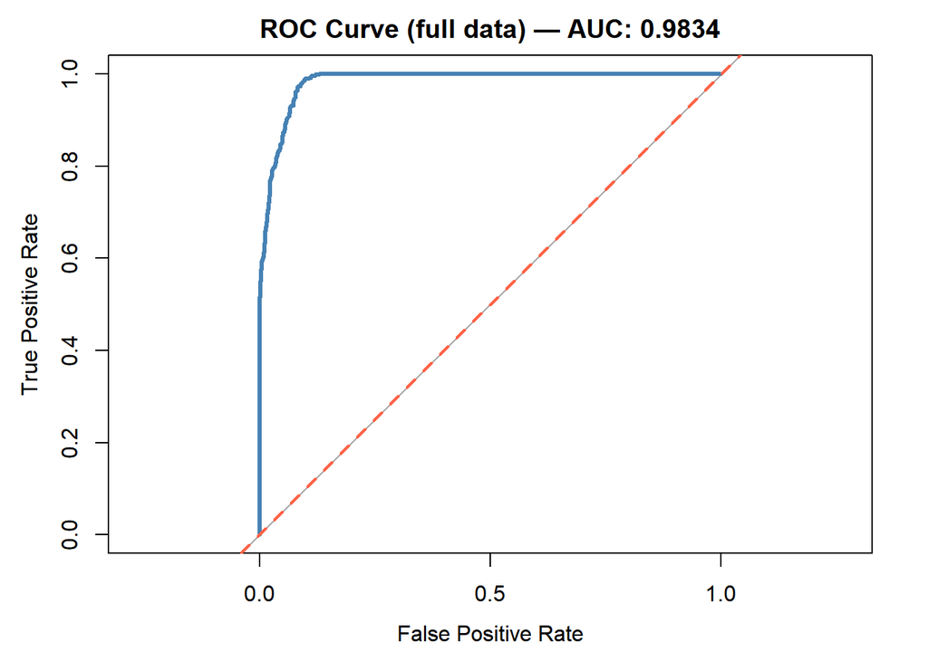

```r
# ROC curve
plot(roc_dropout,
     col         = "steelblue",
     lwd         = 3,
     legacy.axes = TRUE,
     main        = paste("ROC Curve (full data) — AUC:", round(auc(roc_dropout), 4)),
     xlab        = "False Positive Rate",
     ylab        = "True Positive Rate")
abline(a = 1, b = -1, lty = 2, col = "tomato", lwd = 2)
```

### 4.2 GPA

We now repeat the same exercise for the continuous outcome GPA. Two adjustments are needed relative to the Dropout model. First, we use `family = gaussian()` instead of `binomial()`, since GPA is a continuous outcome — each candidate learner is now fitted as a regression model and predictions are returned on the original continuous scale rather than as probabilities. Second, AUC is no longer a meaningful performance measure as it is specific to binary classification. We replace it with the $R^2$ which captures the proportion of variance in GPA explained by the model. A value close to 1 indicates near-perfect predictions, while a value near 0 means the model does no better than always predicting the sample mean.

```r
# Define feature matrix
X_gpa <- df %>% select(-Dropout, -GPA)

# Fit Super Learner on full data
sl_fit_gpa <- SuperLearner(
  Y          = df$GPA,
  X          = X_gpa,
  SL.library = SL.library,
  family     = gaussian(),
  method     = "method.NNLS",
  cvControl  = list(V = 5)
)

sl_fit_gpa
```

```
##
## Call:
## SuperLearner(Y = df$GPA, X = X_gpa, family = gaussian(), SL.library = SL.library,
##     method = "method.NNLS", cvControl = list(V = 5))
##
##
##                    Risk      Coef
## SL.mean_All   1.1039637 0.0000000
## SL.glm_All    0.8228621 0.4782804
## SL.ranger_All 0.8520989 0.1639532
## SL.gam_All    0.8229068 0.3577663
## SL.earth_All  0.8399806 0.0000000
```

```r
# In-sample predictions
Y_hat_gpa <- predict(sl_fit_gpa, newdata = X_gpa)$pred

# MSE
mse_gpa <- mean((df$GPA - Y_hat_gpa)^2)
cat("In-sample MSE:", round(mse_gpa, 4), "\n")
```

```
## In-sample MSE: 0.6697
```

```r
# R-squared
r2_gpa <- 1 - mse_gpa / var(df$GPA)
cat("In-sample R-squared:", round(r2_gpa, 4), "\n")
```

```
## In-sample R-squared: 0.3929
```

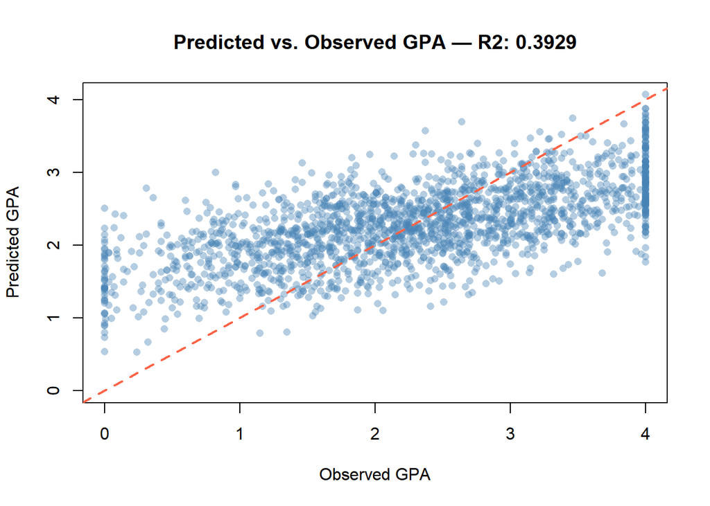

```r
# Predicted vs. actual
plot(df$GPA, Y_hat_gpa,
     col  = adjustcolor("steelblue", alpha.f = 0.4),
     pch  = 16,
     xlab = "Observed GPA",
     ylab = "Predicted GPA",
     main = paste("Predicted vs. Observed GPA — R2:", round(r2_gpa, 4)),
     ylim = c(0, max(Y_hat_gpa)))
abline(a = 0, b = 1, lty = 2, col = "tomato", lwd = 2)
```

## 5. Cross-Validated Risk of the Super Learner

In Section 4 we evaluated performance on the same data used for training, which leads to optimistically biased estimates — the model has already “seen” the outcomes. To obtain honest, generalization estimates of the risk, we use `CV.SuperLearner()`, which wraps the entire Super Learner procedure in an outer cross-validation loop. In each fold, a fresh Super Learner (including its own inner cross-validation for weight estimation) is trained on the remaining data and evaluated on the held-out fold. The result is a cross-validated risk estimate for each candidate learner and for the ensemble itself, which we can compare fairly.

### 5.1 Dropout

```r
cv_sl_dropout <- CV.SuperLearner(
  Y              = df$Dropout,
  X              = X_dropout,
  SL.library     = SL.library,
  family         = binomial(),
  method         = "method.NNLS",
  cvControl      = list(V = 5),
  innerCvControl = list(list(V = 5))
)

summary(cv_sl_dropout)
```

```
##
## Call:
## CV.SuperLearner(Y = df$Dropout, X = X_dropout, family = binomial(), SL.library = SL.library,
##     method = "method.NNLS", cvControl = list(V = 5), innerCvControl = list(list(V = 5)))
##
##
## Risk is based on: Mean Squared Error
##
## All risk estimates are based on V =  5
##
##      Algorithm     Ave        se     Min     Max
##  Super Learner 0.13641 0.0047018 0.12833 0.14134
##    Discrete SL 0.13759 0.0048499 0.12895 0.14242
##    SL.mean_All 0.18707 0.0049861 0.16821 0.20078
##     SL.glm_All 0.13759 0.0048499 0.12895 0.14242
##  SL.ranger_All 0.13936 0.0045386 0.13125 0.14447
##     SL.gam_All 0.13875 0.0048999 0.12948 0.14531
##   SL.earth_All 0.14438 0.0054148 0.13716 0.15728
```

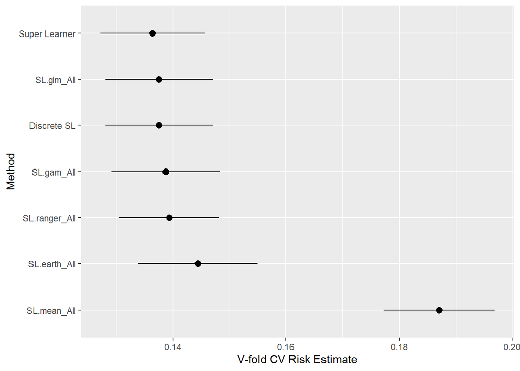

```r
plot(cv_sl_dropout)
```

### 5.2 GPA

```r
cv_sl_gpa <- CV.SuperLearner(
  Y              = df$GPA,
  X              = X_gpa,
  SL.library     = SL.library,
  family         = gaussian(),
  method         = "method.NNLS",
  cvControl      = list(V = 5),
  innerCvControl = list(list(V = 5))
)

summary(cv_sl_gpa)
```

```
##
## Call:
## CV.SuperLearner(Y = df$GPA, X = X_gpa, family = gaussian(), SL.library = SL.library,
##     method = "method.NNLS", cvControl = list(V = 5), innerCvControl = list(list(V = 5)))
##
##
## Risk is based on: Mean Squared Error
##
## All risk estimates are based on V =  5
##
##      Algorithm     Ave       se     Min     Max
##  Super Learner 0.82723 0.023902 0.73580 0.89452
##    Discrete SL 0.82686 0.024029 0.73546 0.89046
##    SL.mean_All 1.10407 0.028676 1.00387 1.24407
##     SL.glm_All 0.82596 0.023841 0.73546 0.89046
##  SL.ranger_All 0.86998 0.024463 0.78021 0.95271
##     SL.gam_All 0.82624 0.024117 0.73032 0.89213
##   SL.earth_All 0.86331 0.025254 0.76241 0.94538
```

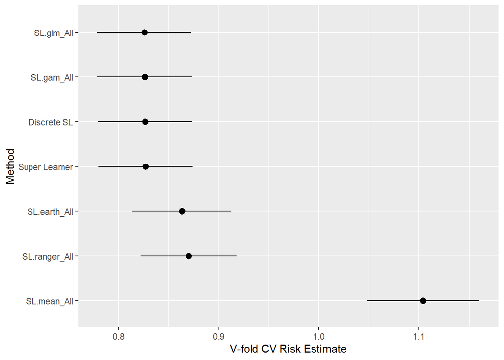

```r
plot(cv_sl_gpa)
```

## 6. Super Learner with Cross-Fitting

In Section 4 we obtained in-sample predictions, and in Section 5 we used `CV.SuperLearner()` to estimate the risk. Here we implement **cross-fitting** (also known as sample splitting) manually. The data are split into $K = 5$ folds; in each fold, the Super Learner is trained on the remaining $K-1$ folds and predictions are generated for the held-out fold. Stacking the out-of-fold predictions gives a full prediction vector that is independent of the training data used to produce it — a property that is crucial in causal machine learning as it avoids overfitting bias in downstream estimation.

### 6.1 Dropout

```r
n_folds <- 5
N       <- nrow(df)
fold_id <- sample(rep(1:n_folds, length.out = N))
folds   <- split(seq_len(N), fold_id)

# Container for out-of-fold predictions
Y_hat_dropout_cf <- numeric(N)

for (k in 1:n_folds) {

  test  <- folds[[k]]
  train <- setdiff(seq_len(N), test)

  sl_fit_dropout_cf <- SuperLearner(
    Y          = df$Dropout[train],
    X          = X_dropout[train, ],
    SL.library = SL.library,
    family     = binomial(),
    method     = "method.NNLS",
    cvControl  = list(V = 5)
  )

  # Predict on held-out fold
  Y_hat_dropout_cf[test] <- predict(sl_fit_dropout_cf, newdata = X_dropout[test, ])$pred
}

# MSE
mse_dropout_cf <- mean((df$Dropout - Y_hat_dropout_cf)^2)
cat("Cross-fitted MSE:", round(mse_dropout_cf, 4), "\n")
```

```
## Cross-fitted MSE: 0.1367
```

```r
# AUC
roc_dropout_cf <- roc(df$Dropout, Y_hat_dropout_cf)
cat("Cross-fitted AUC:", round(auc(roc_dropout_cf), 4), "\n")
```

```
## Cross-fitted AUC: 0.8225
```

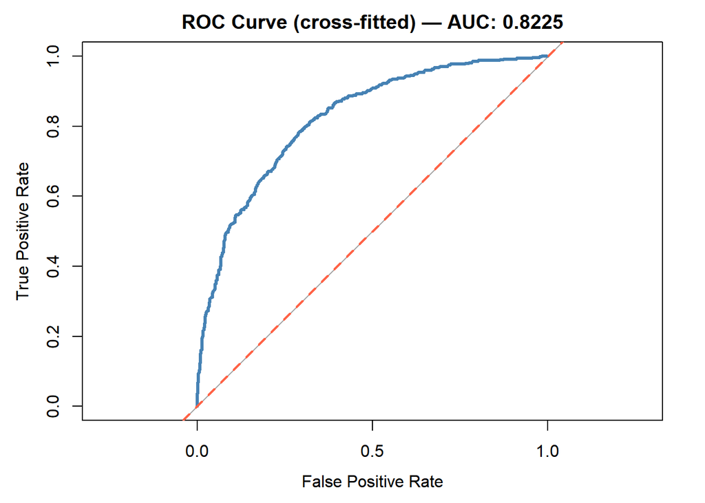

```r
# ROC curve
plot(roc_dropout_cf,
     col         = "steelblue",
     lwd         = 3,
     legacy.axes = TRUE,
     main        = paste("ROC Curve (cross-fitted) — AUC:", round(auc(roc_dropout_cf), 4)),
     xlab        = "False Positive Rate",
     ylab        = "True Positive Rate")
abline(a = 1, b = -1, lty = 2, col = "tomato", lwd = 2)
```

### 6.2 GPA

```r
# Container for out-of-fold predictions
Y_hat_gpa_cf <- numeric(N)

for (k in 1:n_folds) {

  test  <- folds[[k]]
  train <- setdiff(seq_len(N), test)

  sl_fit_gpa_cf <- SuperLearner(
    Y          = df$GPA[train],
    X          = X_gpa[train, ],
    SL.library = SL.library,
    family     = gaussian(),
    method     = "method.NNLS",
    cvControl  = list(V = 5)
  )

  # Predict on held-out fold
  Y_hat_gpa_cf[test] <- predict(sl_fit_gpa_cf, newdata = X_gpa[test, ])$pred
}

# MSE
mse_gpa_cf <- mean((df$GPA - Y_hat_gpa_cf)^2)
cat("Cross-fitted MSE:", round(mse_gpa_cf, 4), "\n")
```

```
## Cross-fitted MSE: 0.8288
```

```r
# R-squared
r2_gpa_cf <- 1 - mse_gpa_cf / var(df$GPA)
cat("Cross-fitted R-squared:", round(r2_gpa_cf, 4), "\n")
```

```
## Cross-fitted R-squared: 0.2486
```

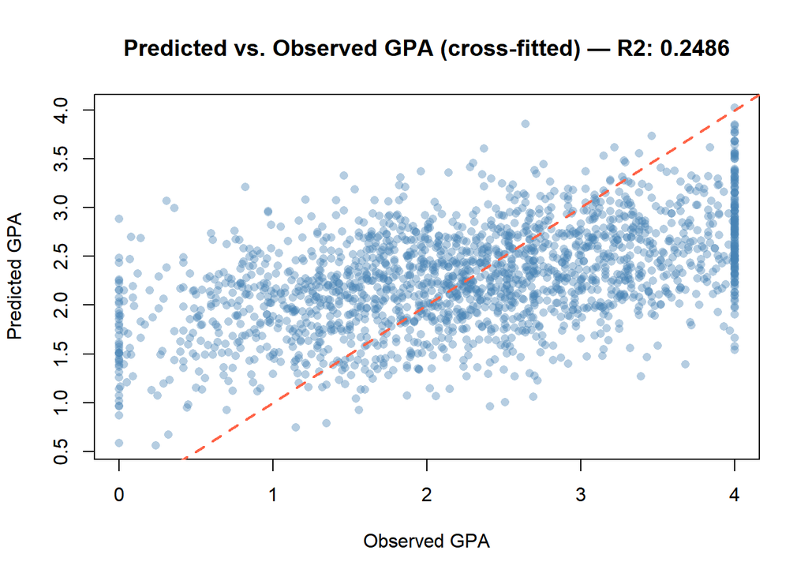

```r
# Predicted vs. actual
plot(df$GPA, Y_hat_gpa_cf,
     col  = adjustcolor("steelblue", alpha.f = 0.4),
     pch  = 16,
     xlab = "Observed GPA",
     ylab = "Predicted GPA",
     main = paste("Predicted vs. Observed GPA (cross-fitted) — R2:", round(r2_gpa_cf, 4)))
abline(a = 0, b = 1, lty = 2, col = "tomato", lwd = 2)
```

## 7. Tuning Base Learners with `create.Learner()`

So far we used default hyperparameters for each candidate learner. The `create.Learner()` function lets us expand the library by creating multiple variants of the same algorithm across a grid of hyperparameters — each variant becomes a separate candidate in the ensemble. This gives the Super Learner more flexibility: it can assign higher weight to the best-performing configuration, or blend across them.

- **Random Forest** (`SL.ranger`): we vary `mtry` (number of features considered at each split) and `num.trees`.
- **MARS** (`SL.earth`): we vary `degree` (maximum interaction depth).

### 7.1 Define tuned learners

```r
# Tuned random forests
learners_ranger <- create.Learner(
  "SL.ranger",
  tune = list(
    mtry      = floor(sqrt(ncol(X_dropout)) * c(0.5, 1, 2)),
    num.trees = c(100, 500)
  )
)

# Tuned MARS
learners_earth <- create.Learner(
  "SL.earth",
  tune = list(
    degree = c(1, 2)
  )
)

# Tuned xgboost
learners_xgboost <- create.Learner(
  "SL.xgboost",
  tune = list(
    max_depth = c(2, 4, 6)
  )
)

learners_ranger
```

```
## $grid
##   mtry num.trees
## 1    2       100
## 2    4       100
## 3    8       100
## 4    2       500
## 5    4       500
## 6    8       500
##
## $names
## [1] "SL.ranger_1" "SL.ranger_2" "SL.ranger_3" "SL.ranger_4" "SL.ranger_5"
## [6] "SL.ranger_6"
##
## $base_learner
## [1] "SL.ranger"
##
## $params
## list()
```

```r
learners_earth
```

```
## $grid
##   degree
## 1      1
## 2      2
##
## $names
## [1] "SL.earth_1" "SL.earth_2"
##
## $base_learner
## [1] "SL.earth"
##
## $params
## list()
```

```r
# Expanded library
SL.library_tuned <- c(
  "SL.mean",
  "SL.glm",
  "SL.gam",
  learners_ranger$names,
  learners_earth$names,
  learners_xgboost$names
)


cat("Candidate learners:\n")
```

```
## Candidate learners:
```

```r
print(SL.library_tuned)
```

```
##  [1] "SL.mean"      "SL.glm"       "SL.gam"       "SL.ranger_1"  "SL.ranger_2"
##  [6] "SL.ranger_3"  "SL.ranger_4"  "SL.ranger_5"  "SL.ranger_6"  "SL.earth_1"
## [11] "SL.earth_2"   "SL.xgboost_1" "SL.xgboost_2" "SL.xgboost_3"
```

### 7.2 CV.SuperLearner — Dropout

```r
cv_sl_tuned_dropout <- CV.SuperLearner(
  Y              = df$Dropout,
  X              = X_dropout,
  SL.library     = SL.library_tuned,
  family         = binomial(),
  method         = "method.NNLS",
  cvControl      = list(V = 5),
  innerCvControl = list(list(V = 5))
)

summary(cv_sl_tuned_dropout)
```

```
##
## Call:
## CV.SuperLearner(Y = df$Dropout, X = X_dropout, family = binomial(), SL.library = SL.library_tuned,
##     method = "method.NNLS", cvControl = list(V = 5), innerCvControl = list(list(V = 5)))
##
##
## Risk is based on: Mean Squared Error
##
## All risk estimates are based on V =  5
##
##         Algorithm     Ave        se     Min     Max
##     Super Learner 0.13795 0.0047643 0.12843 0.14478
##       Discrete SL 0.13879 0.0049112 0.12522 0.14773
##       SL.mean_All 0.18712 0.0049882 0.16942 0.20462
##        SL.glm_All 0.13820 0.0048635 0.12522 0.14773
##        SL.gam_All 0.13881 0.0049178 0.12597 0.14763
##   SL.ranger_1_All 0.14385 0.0044440 0.13351 0.14997
##   SL.ranger_2_All 0.14118 0.0045954 0.13311 0.14784
##   SL.ranger_3_All 0.14287 0.0048123 0.13625 0.14869
##   SL.ranger_4_All 0.14339 0.0043915 0.13408 0.15073
##   SL.ranger_5_All 0.13971 0.0045691 0.13172 0.14572
##   SL.ranger_6_All 0.14033 0.0047206 0.13371 0.14700
##    SL.earth_1_All 0.14223 0.0050263 0.13307 0.14982
##    SL.earth_2_All 0.14948 0.0054747 0.13692 0.15571
##  SL.xgboost_1_All 0.15491 0.0059272 0.14110 0.16187
##  SL.xgboost_2_All 0.16733 0.0067823 0.15744 0.18000
##  SL.xgboost_3_All 0.16519 0.0068553 0.15556 0.17950
```

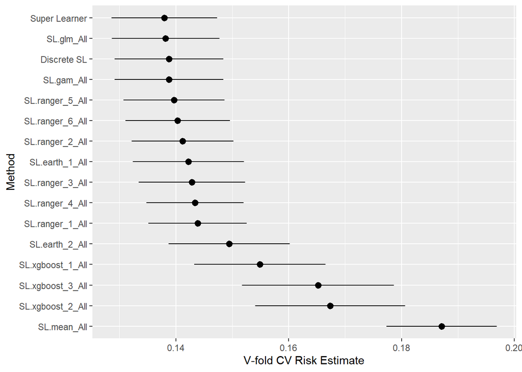

```r
plot(cv_sl_tuned_dropout)
```

### 7.3 CV.SuperLearner — GPA

```r
cv_sl_tuned_gpa <- CV.SuperLearner(
  Y              = df$GPA,
  X              = X_gpa,
  SL.library     = SL.library_tuned,
  family         = gaussian(),
  method         = "method.NNLS",
  cvControl      = list(V = 5),
  innerCvControl = list(list(V = 5))
)

summary(cv_sl_tuned_gpa)
```

```
##
## Call:
## CV.SuperLearner(Y = df$GPA, X = X_gpa, family = gaussian(), SL.library = SL.library_tuned,
##     method = "method.NNLS", cvControl = list(V = 5), innerCvControl = list(list(V = 5)))
##
##
## Risk is based on: Mean Squared Error
##
## All risk estimates are based on V =  5
##
##         Algorithm     Ave       se     Min     Max
##     Super Learner 0.83279 0.023866 0.73711 0.90101
##       Discrete SL 0.83175 0.023945 0.73233 0.90620
##       SL.mean_All 1.10327 0.028669 1.03283 1.17087
##        SL.glm_All 0.82878 0.023852 0.73233 0.90620
##        SL.gam_All 0.83188 0.024113 0.73592 0.90532
##   SL.ranger_1_All 0.89907 0.024068 0.80552 0.93956
##   SL.ranger_2_All 0.87201 0.024334 0.78763 0.90635
##   SL.ranger_3_All 0.87898 0.025083 0.78771 0.92236
##   SL.ranger_4_All 0.89950 0.024058 0.80511 0.93816
##   SL.ranger_5_All 0.86777 0.024003 0.78410 0.91125
##   SL.ranger_6_All 0.86715 0.024553 0.77506 0.92157
##    SL.earth_1_All 0.84295 0.024248 0.74875 0.90531
##    SL.earth_2_All 0.85750 0.024844 0.74965 0.94876
##  SL.xgboost_1_All 0.95826 0.028222 0.87664 1.00493
##  SL.xgboost_2_All 1.06921 0.031775 0.97078 1.14391
##  SL.xgboost_3_All 1.02826 0.030185 0.93846 1.10322
```

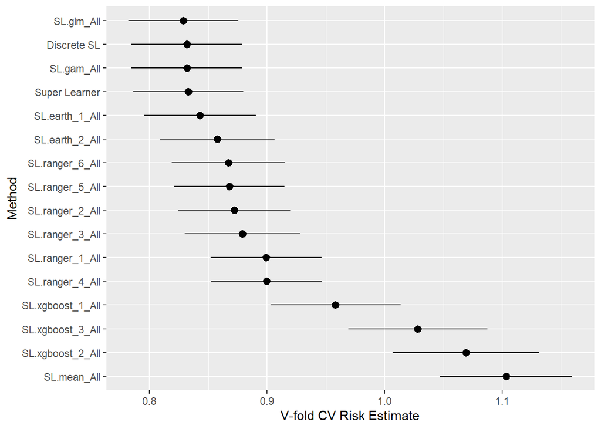

```r
plot(cv_sl_tuned_gpa)
```

## 8. Cross-Fitting with Tuned Library

We now repeat the cross-fitting procedure from Section 6 using the expanded, tuned library defined in Section 7. This lets us assess whether the additional hyperparameter variants improve out-of-fold predictive performance relative to the default library.

### 8.1 Dropout

```r
Y_hat_dropout_cf_tuned <- numeric(N)

for (k in 1:n_folds) {

  test  <- folds[[k]]
  train <- setdiff(seq_len(N), test)

  sl_fit <- SuperLearner(
    Y          = df$Dropout[train],
    X          = X_dropout[train, ],
    SL.library = SL.library_tuned,
    family     = binomial(),
    method     = "method.NNLS",
    cvControl  = list(V = 5)
  )

  Y_hat_dropout_cf_tuned[test] <- predict(sl_fit, newdata = X_dropout[test, ])$pred
}

mse_dropout_cf_tuned <- mean((df$Dropout - Y_hat_dropout_cf_tuned)^2)
roc_dropout_cf_tuned <- roc(df$Dropout, Y_hat_dropout_cf_tuned)

cat("Cross-fitted MSE (tuned):", round(mse_dropout_cf_tuned, 4), "\n")
```

```
## Cross-fitted MSE (tuned): 0.137
```

```r
cat("Cross-fitted AUC (tuned):", round(auc(roc_dropout_cf_tuned), 4), "\n")
```

```
## Cross-fitted AUC (tuned): 0.8225
```

### 8.2 GPA

```r
Y_hat_gpa_cf_tuned <- numeric(N)

for (k in 1:n_folds) {

  test  <- folds[[k]]
  train <- setdiff(seq_len(N), test)

  sl_fit <- SuperLearner(
    Y          = df$GPA[train],
    X          = X_gpa[train, ],
    SL.library = SL.library_tuned,
    family     = gaussian(),
    method     = "method.NNLS",
    cvControl  = list(V = 5)
  )

  Y_hat_gpa_cf_tuned[test] <- predict(sl_fit, newdata = X_gpa[test, ])$pred
}

mse_gpa_cf_tuned    <- mean((df$GPA - Y_hat_gpa_cf_tuned)^2)
r2_gpa_cf_tuned     <- 1 - mse_gpa_cf_tuned / var(df$GPA)

cat("Cross-fitted MSE (tuned):", round(mse_gpa_cf_tuned, 4), "\n")
```

```
## Cross-fitted MSE (tuned): 0.8298
```

```r
cat("Cross-fitted R-squared (tuned):", round(r2_gpa_cf_tuned, 4), "\n")
```

```
## Cross-fitted R-squared (tuned): 0.2476
```

### 8.3 Comparison with default library

```r
comparison <- data.frame(
  Outcome = c("Dropout", "Dropout", "GPA", "GPA"),
  Library = c("Default", "Tuned", "Default", "Tuned"),
  MSE     = c(mse_dropout_cf,      mse_dropout_cf_tuned,
              mse_gpa_cf,          mse_gpa_cf_tuned),
  Metric2 = c(round(auc(roc_dropout_cf), 4), round(auc(roc_dropout_cf_tuned), 4),
              r2_gpa_cf,                      r2_gpa_cf_tuned),
  Metric2_name = c("AUC", "AUC", "R2", "R2")
)

print(comparison)
```

```
##   Outcome Library       MSE   Metric2 Metric2_name
## 1 Dropout Default 0.1366645 0.8225000          AUC
## 2 Dropout   Tuned 0.1370357 0.8225000          AUC
## 3     GPA Default 0.8287507 0.2486370           R2
## 4     GPA   Tuned 0.8298458 0.2476442           R2
```

### Bonus

```r
# Tuned glmnet: grid over alpha (0 = ridge, 1 = lasso, in-between = elastic net)
# and lambda is chosen internally by glmnet via cross-validation
learners_glmnet <- create.Learner(
  "SL.glmnet",
  tune = list(alpha = c(0, 0.5, 1))
)

learners_glmnet$names  # SL.glmnet_1, SL.glmnet_2, SL.glmnet_3
```

```
## [1] "SL.glmnet_1" "SL.glmnet_2" "SL.glmnet_3"
```